# module4

GroupeB

2025-02-15

### Exercice1 :

- Description des hypothèses nulles : Pour chaque variable, l’hypothèse nulle stipule que cette qu’elle n’a aucun effet significatif sur les ventes. C’est à dire :
  - TV ; H_0 : ” Les dépenses en publicité télévisée n’ont pas d’effet sur les ventes.”
  - Radio ; H_0: “Les dépenses en publicité radio n’ont pas d’effet sur les ventes.”
  - Journaux ; H_0 : “Les dépenses en publicité dans les journaux n’ont pas d’effet sur les ventes.”
  - Intercept ; H_0 : “La variable de référence (elle n’est pas explicitement mentionnée dans le cadre de l’exercice) est non négligeable lorsque toutes les variables indépendantes sont nulles.”

  **Interprétation des résultats** :

Publicité télévisée et radio : un effet significatif sur les ventes

Les valeurs p pour la TV (<0.0001) et la radio (<0.0001) sont très faibles. Cela signifie que nous rejetons l’hypothèse nulle dans ces deux cas : il y a des preuves statistiques fortes que la publicité télévisée et la publicité radio ont un effet significatif sur les ventes. Publicité dans les journaux : pas d’effet significatif sur les ventes

La valeur p de la publicité dans les journaux (0.8599) est très élevée. Cela signifie que nous ne rejetons pas l’hypothèse nulle : il n’y a pas de preuve statistique que la publicité dans les journaux ait un impact sur les ventes. Autrement dit, investir dans ce type de publicité ne semble pas influencer significativement les ventes. Intercept : significatif

La valeur p associée à l’intercept est <0.0001, donc on rejette l’hypothèse nulle. Cela suggère qu’il existe un niveau de ventes de base même en l’absence de dépenses publicitaires.

Finalement, Les entreprises devraient privilégier la publicité télévisée et radio pour augmenter les ventes, car ces deux formes de publicité ont un impact statistiquement significatif.

### Exercice 2:

#### a) Choix de la bonne réponse :

Nous avons
$$\hat{y} = \beta _0\times +
\beta _1\times GPA + \beta _2 \times QI
+ \beta _3\times Level + \beta _4\times(GPA\times QI) + \beta
_5\times(GPA\times Level) + \epsilon$$

où :

- Level 1 est pour les diplômés du collège ;
- Level 2 pour ceux du secondaire
- Pour un diplômé du Lycée,(Level = 0), on a

$$\hat{y}_{Lycee} = \beta _0 +\beta _1
\times GPA + \beta _2 \times QI + \beta _4 \times GPA \times QI$$

- Pour un diplômé du collège = universitaire : (Level = 1) on a

$$\hat{y}_{col} = \beta _0 +\beta _1
\times GPA + \beta _2 \times QI + \beta _3 + \beta _4 \times (GPA \times
QI) + \beta _5 \times GPA$$

- On évalue maintenant la différence pour pouvoir comparer :

$$\hat{y}_{col} - \hat{y}_{lycee} = (beta
_0 +\beta _1 \times GPA + \beta _2 \times QI + \beta _3 + \beta _4
\times (GPA \times QI) + \beta _5 \times GPA) - (\beta _0 +\beta _1
\times GPA + \beta _2 \times QI + \beta _4 \times GPA \times
QI)$$

$$\hat{y}_{col} - \hat{y}_{lycee} = \beta
_3 + \beta _5 \times GPA$$
La bonne réponse est

iV ) Pour une valeur fixe de QI et de GPA, les diplômés universitaires gagnent en moyenne plus que les diplômés du secondaire, à condition que la GPA soit suffisamment élevée. Mais pour que ça marche, il faut bien sûr que $\beta_3 >0$

#### b)

Prédiction du salaire d’un diplômé universitaire avec un QI de 110 et une moyenne cumulative de 4,0.

$$\hat{y}_{col} = \beta _0 +\beta _1
\times GPA + \beta _2 \times QI + \beta _3 + \beta _4 \times (GPA \times
QI) + \beta _5 \times GPA$$
$$\hat{y}_{col} = \beta _0 +\beta _1 \times 4.5 + \beta _2 \times 110 +
\beta _3 + \beta _4 \times (4.0 \times 110) + \beta _5 \times 4.0$$
$$\hat{y}_{col} = \beta _0 +4.0
\beta _1 + 110 \beta _2 + \beta _3 + 440.0 \beta _4 + 4 \beta
_5$$
Il manque les coefficients $\beta_i$ pour donner une prédiction numerique.

#### c ) Réponse :

Faux, ce n’est pas la valeur d’un coefficient qui détermine son interaction ou non, mais plutôt la p-value.

### Question 3 :

a ) On s’attend à ce que la RSS du modèle cubique soit plus petit que celle du modèle linéaire sur les données d’entrainement. Par ce que le modèle cubique a plus de paramètres et capte plus de bruit, ce qui réduit significativement sa RSE.

2. regression linéaire : y_hat = a + bX

Regression cubique : y_hat = a + bX + c X^2 + d X^3

Hypothèse nulle : c = d = 0

Si l’hypothèse nulle est rejeté (p-value significativement petit), alors le modèle cubique s’ajuste mieux aux donnée.

c ) (pas sur !) En toutes circonstances, la regression quadratique capte plus de bruit que la regression lineaire. Donc la RSE est necessairement plus petite si elle est calculée sur les données test.

### Question 4 :

Question incomplete

### Question 5 :

Démontrons que dans le cas d’une régression linéaire simple, la droite des moindres carrés passe toujours par le point moyen $G(\overline{x}, \overline{y})$.

L’équation d’une regression linéaire simple est donnée par $\hat{y} = a X + b + \epsilon$

où
$$b= \frac{\sum(x_i -
\overline{x})(y_i - \overline{y})}{\sum(x_i - \overline{x})^2}$$
et
$$b = \overline{y} - a
\overline{x}$$
dès lors,
$$a\overline{x} +b +\epsilon = a\overline{x} +
\overline{y} - a \overline{x} \approx \overline{y}$$
cqfd.

### Question 6

incomplet

## Pratique:

### Exercice 1

#### a)

```r
modele_lineaire <- lm(mpg ~ horsepower, data = Auto)
summary(modele_lineaire)
```

```
##
## Call:
## lm(formula = mpg ~ horsepower, data = Auto)
##
## Residuals:
##      Min       1Q   Median       3Q      Max
## -13.5710  -3.2592  -0.3435   2.7630  16.9240
##
## Coefficients:
##              Estimate Std. Error t value Pr(>|t|)
## (Intercept) 39.935861   0.717499   55.66   <2e-16 ***
## horsepower  -0.157845   0.006446  -24.49   <2e-16 ***
## ---
## Signif. codes:  0 '***' 0.001 '**' 0.01 '*' 0.05 '.' 0.1 ' ' 1
##
## Residual standard error: 4.906 on 390 degrees of freedom
## Multiple R-squared:  0.6059, Adjusted R-squared:  0.6049
## F-statistic: 599.7 on 1 and 390 DF,  p-value: < 2.2e-16
```

##### i )

**p-value: < 2.2e-16** –> oui il existe une relation entre le prédicteur et la réponse ?

##### ii )

force de la relation entre le prédicteur et la réponse : **R^2 0.6059** –> 60.59 % de la variabilité des prédictions de mpg à partir de horsepower sont expliquées par le modèle.

##### iii )

Signe de la relation : horsepower = -0.157845, c-a-d $_ 1 <0 –> $ les deux variables évoluent en sens contraire.

##### iv )

mpg prévu associé à une puissance de 98 chevaux ?

```r
predire_mpg <- function(horsepower) {
  b_0 <- 39.935861
  b_1 <- -0.157845
  return(b_0 + b_1 * horsepower)
}
predire_mpg(98)
```

```
## [1] 24.46705
```

La valeur prédite pour 98 cheveaux est **mpg_hat = 24.47**

#### b)

graphique entre la réponse (mpg) et le prédicteur.

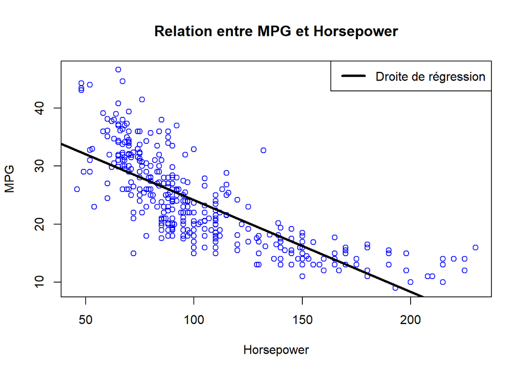

```r
plot(Auto$horsepower, Auto$mpg,
     main = "Relation entre MPG et Horsepower",
     xlab = "Horsepower",
     ylab = "MPG",
     col = "blue")
abline(modele_lineaire, col = "black",lwd = 3)
legend("topright", legend = "Droite de régression", col = "black", lwd = 3)
```

#### c)

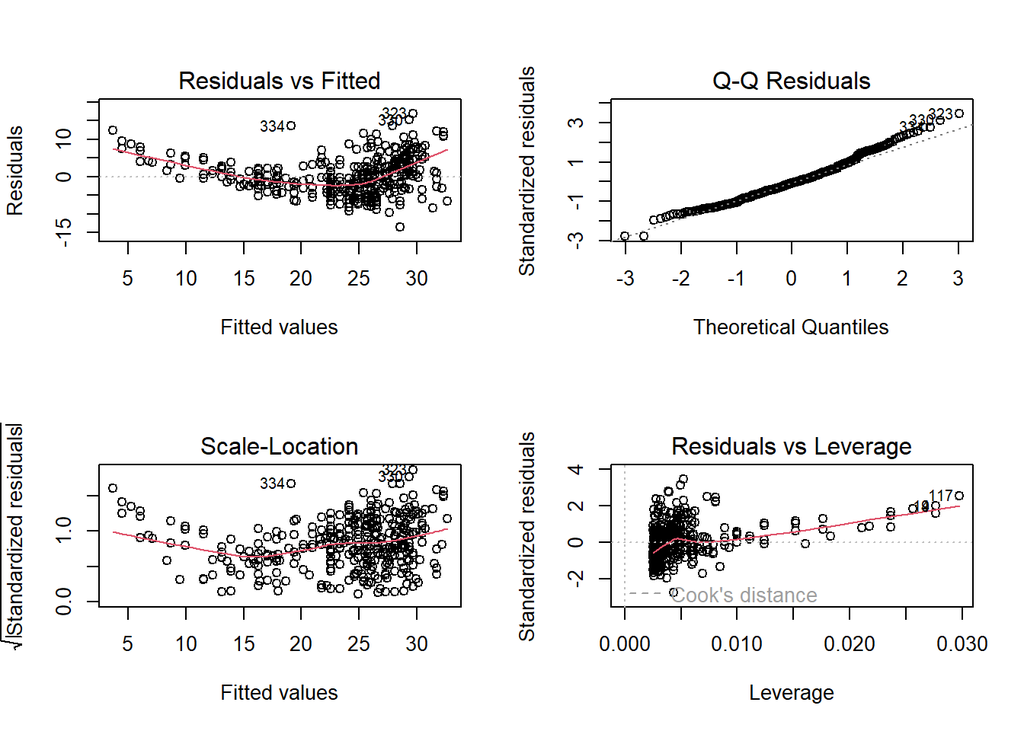

```r
# Générer les diagnostics du modèle
par(mfrow = c(2, 2))
plot(modele_lineaire)
```

commentaires :

- La distribution des résidus a une forme quadratique,, ce qui pose problème, elle ne doit pas avoir une répartition perceptible
- Le diagramme Quantiles-quantile a une forme lineaire –> Les résidus suivent une distribution normale

### Question 2

Cette question implique l’utilisation d’une régression linéaire multiple sur l’ensemble de données Auto.

#### a)

Produisons une matrice de nuages de points qui inclut toutes les variables de l’ensemble de données.

```r
library(ISLR)
```

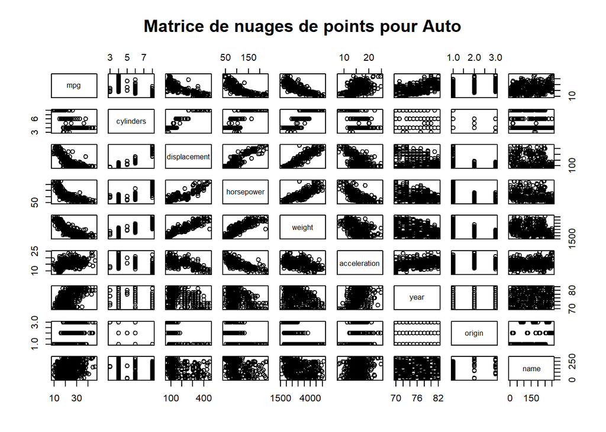

```r
data(Auto)
pairs(Auto, main = "Matrice de nuages de points pour Auto")
```

#### b)

Calculons la matrice des corrélations entre les variables à l’aide de la fonction cor(). nous devions exclure la variable name qui est qualitative.

```r
data(Auto)
#Extrait la variable "name"
Auto_numeric <- Auto[, -which(names(Auto) == "name")]

#Calculons la matrice des corrélations
cor_matrix <- cor(Auto_numeric)

print(round(cor_matrix, 2))
```

```
##                mpg cylinders displacement horsepower weight acceleration  year
## mpg           1.00     -0.78        -0.81      -0.78  -0.83         0.42  0.58
## cylinders    -0.78      1.00         0.95       0.84   0.90        -0.50 -0.35
## displacement -0.81      0.95         1.00       0.90   0.93        -0.54 -0.37
## horsepower   -0.78      0.84         0.90       1.00   0.86        -0.69 -0.42
## weight       -0.83      0.90         0.93       0.86   1.00        -0.42 -0.31
## acceleration  0.42     -0.50        -0.54      -0.69  -0.42         1.00  0.29
## year          0.58     -0.35        -0.37      -0.42  -0.31         0.29  1.00
## origin        0.57     -0.57        -0.61      -0.46  -0.59         0.21  0.18
##              origin
## mpg            0.57
## cylinders     -0.57
## displacement  -0.61
## horsepower    -0.46
## weight        -0.59
## acceleration   0.21
## year           0.18
## origin         1.00
```

#### c)

Utilisons la fonction lm() pour effectuer une régression linéaire multiple avec mpg comme réponse et toutes les autres variables sauf le nom comme prédicteurs. Utilisez la fonction summary() pour imprimer les résultats. Commentons le résultat. Par exemple:

i- Existe-t-il une relation entre les prédicteurs et la réponse ?

**p-value < 2.2e-16 pour le test F, ce qui indique confirment qu’il existe une forte relation entre les prédicteurs choisis et mpg, permettant de modéliser efficacement la consommation de carburant des véhicules présents dans le jeu de données Auto.

```r
data(Auto)
modele_multiple <- lm(mpg ~ . - name, data = Auto)
summary(modele_multiple)
```

```
##
## Call:
## lm(formula = mpg ~ . - name, data = Auto)
##
## Residuals:
##     Min      1Q  Median      3Q     Max
## -9.5903 -2.1565 -0.1169  1.8690 13.0604
##
## Coefficients:
##                Estimate Std. Error t value Pr(>|t|)
## (Intercept)  -17.218435   4.644294  -3.707  0.00024 ***
## cylinders     -0.493376   0.323282  -1.526  0.12780
## displacement   0.019896   0.007515   2.647  0.00844 **
## horsepower    -0.016951   0.013787  -1.230  0.21963
## weight        -0.006474   0.000652  -9.929  < 2e-16 ***
## acceleration   0.080576   0.098845   0.815  0.41548
## year           0.750773   0.050973  14.729  < 2e-16 ***
## origin         1.426141   0.278136   5.127 4.67e-07 ***
## ---
## Signif. codes:  0 '***' 0.001 '**' 0.01 '*' 0.05 '.' 0.1 ' ' 1
##
## Residual standard error: 3.328 on 384 degrees of freedom
## Multiple R-squared:  0.8215, Adjusted R-squared:  0.8182
## F-statistic: 252.4 on 7 and 384 DF,  p-value: < 2.2e-16
```

ii- Quels prédicteurs semblent avoir une relation statistiquement significative avec la réponse ?

iii-Que suggère le coefficient de la variable « année »

Le coefficient de la variable «année» est positif d’environ 0,75, ce qui suggère qu’en moyenne, chaque année additionnelle est associée à une augmentation d’environ 0,75 mpg. Autrement dit, les véhicules plus récents tendent à afficher une meilleure efficacité énergétique.

#### d)

Utilisons la fonction plot() pour produire des tracés de diagnostic de l’ajustement de régression linéaire. Commentez tous les problèmes que vous voyez avec l’ajustement.

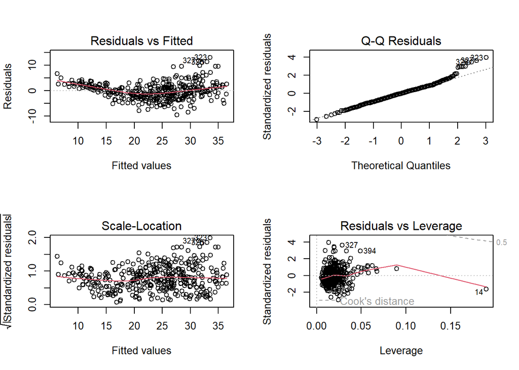

```r
#plaçons les graphe 2 a 2
par(mfrow = c(2, 2))
#graphe
plot(modele_multiple)
```

* Les tracés résiduels suggèrent-ils des valeurs aberrantes inhabituellement importantes ?

- Le graphique de l’effet de levier identifie-t-il des observations présentant un effet de levier inhabituellement élevé ?

#### e)

Utilisez les symboles * et : pour ajuster les modèles de régression linéaire avec des effets d’interaction. Certaines interactions semblent-elles statistiquement significatives ?

Modèle avec interaction entre horsepower et year.

le coefficient d’interaction est négatif et statistiquement significatif car p-value < 0.05, cela suggère que l’effet négatif de horsepower sur mpg devient plus prononcé pour des véhicules plus récents.

le modele avec *

```r
modele_interaction <- lm(mpg ~ horsepower * year, data = Auto)
summary(modele_interaction)
```

```
##
## Call:
## lm(formula = mpg ~ horsepower * year, data = Auto)
##
## Residuals:
##      Min       1Q   Median       3Q      Max
## -12.3492  -2.4509  -0.4557   2.4056  14.4437
##
## Coefficients:
##                   Estimate Std. Error t value Pr(>|t|)
## (Intercept)     -1.266e+02  1.212e+01 -10.449   <2e-16 ***
## horsepower       1.046e+00  1.154e-01   9.063   <2e-16 ***
## year             2.192e+00  1.613e-01  13.585   <2e-16 ***
## horsepower:year -1.596e-02  1.562e-03 -10.217   <2e-16 ***
## ---
## Signif. codes:  0 '***' 0.001 '**' 0.01 '*' 0.05 '.' 0.1 ' ' 1
##
## Residual standard error: 3.901 on 388 degrees of freedom
## Multiple R-squared:  0.7522, Adjusted R-squared:  0.7503
## F-statistic: 392.5 on 3 and 388 DF,  p-value: < 2.2e-16
```

le modele avec :

```r
modele_interaction2 <- lm(mpg ~ horsepower : year, data = Auto)
summary(modele_interaction2)
```

```
##
## Call:
## lm(formula = mpg ~ horsepower:year, data = Auto)
##
## Residuals:
##      Min       1Q   Median       3Q      Max
## -13.7959  -3.5770  -0.4462   3.0817  17.3724
##
## Coefficients:
##                   Estimate Std. Error t value Pr(>|t|)
## (Intercept)      4.045e+01  8.016e-01   50.46   <2e-16 ***
## horsepower:year -2.158e-03  9.621e-05  -22.43   <2e-16 ***
## ---
## Signif. codes:  0 '***' 0.001 '**' 0.01 '*' 0.05 '.' 0.1 ' ' 1
##
## Residual standard error: 5.164 on 390 degrees of freedom
## Multiple R-squared:  0.5634, Adjusted R-squared:  0.5623
## F-statistic: 503.3 on 1 and 390 DF,  p-value: < 2.2e-16
```

#### f)

Essayons quelques transformations différentes des variables, telles que log(X), sqrt(X), X*2 Commentons vos découvertes.

Modèle original : Le modèle utilisant horsepower en l’état fournit une relation significative négative avec mpg.

```r
#Modèle avec la variable originale
model_orig <- lm(mpg ~ horsepower, data = Auto)
summary(model_orig)
```

```
##
## Call:
## lm(formula = mpg ~ horsepower, data = Auto)
##
## Residuals:
##      Min       1Q   Median       3Q      Max
## -13.5710  -3.2592  -0.3435   2.7630  16.9240
##
## Coefficients:
##              Estimate Std. Error t value Pr(>|t|)
## (Intercept) 39.935861   0.717499   55.66   <2e-16 ***
## horsepower  -0.157845   0.006446  -24.49   <2e-16 ***
## ---
## Signif. codes:  0 '***' 0.001 '**' 0.01 '*' 0.05 '.' 0.1 ' ' 1
##
## Residual standard error: 4.906 on 390 degrees of freedom
## Multiple R-squared:  0.6059, Adjusted R-squared:  0.6049
## F-statistic: 599.7 on 1 and 390 DF,  p-value: < 2.2e-16
```

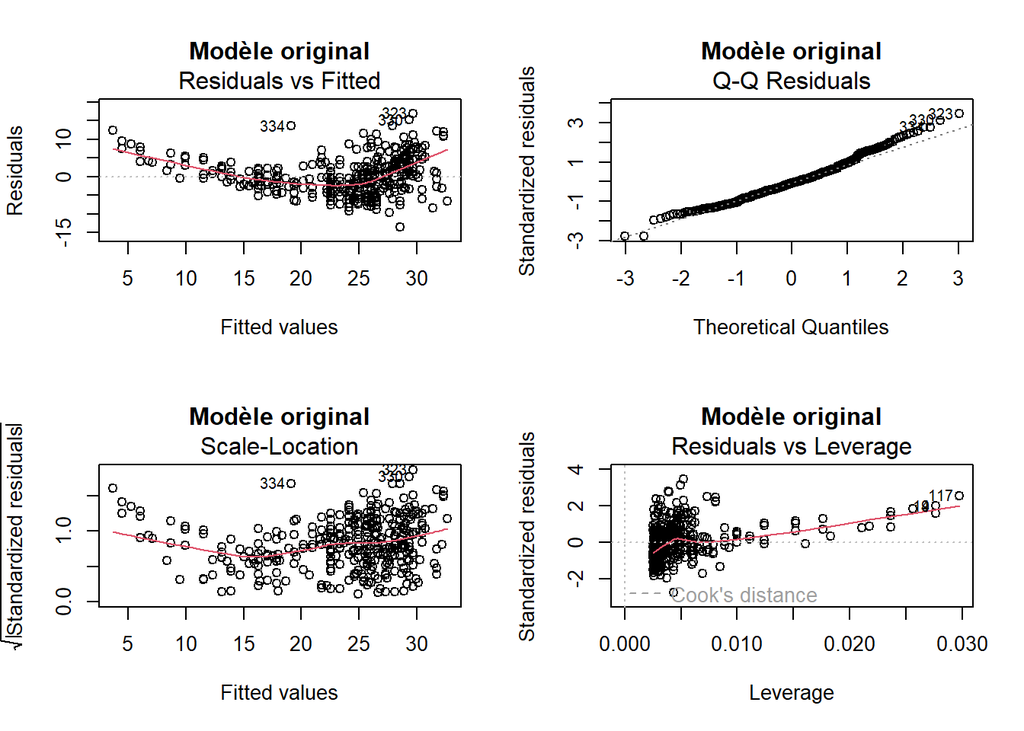

```r
par(mfrow = c(2, 2))
plot(model_orig, main = "Modèle original")
```

Transformation log :L’utilisation de log(horsepower) linéarise la relation qui était autrement curviligne dans le modèle original et montre une de l’ajustement.

```r
# Modèle avec log(horsepower)
model_log <- lm(mpg ~ log(horsepower), data = Auto)
summary(model_log)
```

```
##
## Call:
## lm(formula = mpg ~ log(horsepower), data = Auto)
##
## Residuals:
##      Min       1Q   Median       3Q      Max
## -14.2299  -2.7818  -0.2322   2.6661  15.4695
##
## Coefficients:
##                 Estimate Std. Error t value Pr(>|t|)
## (Intercept)     108.6997     3.0496   35.64   <2e-16 ***
## log(horsepower) -18.5822     0.6629  -28.03   <2e-16 ***
## ---
## Signif. codes:  0 '***' 0.001 '**' 0.01 '*' 0.05 '.' 0.1 ' ' 1
##
## Residual standard error: 4.501 on 390 degrees of freedom
## Multiple R-squared:  0.6683, Adjusted R-squared:  0.6675
## F-statistic: 785.9 on 1 and 390 DF,  p-value: < 2.2e-16
```

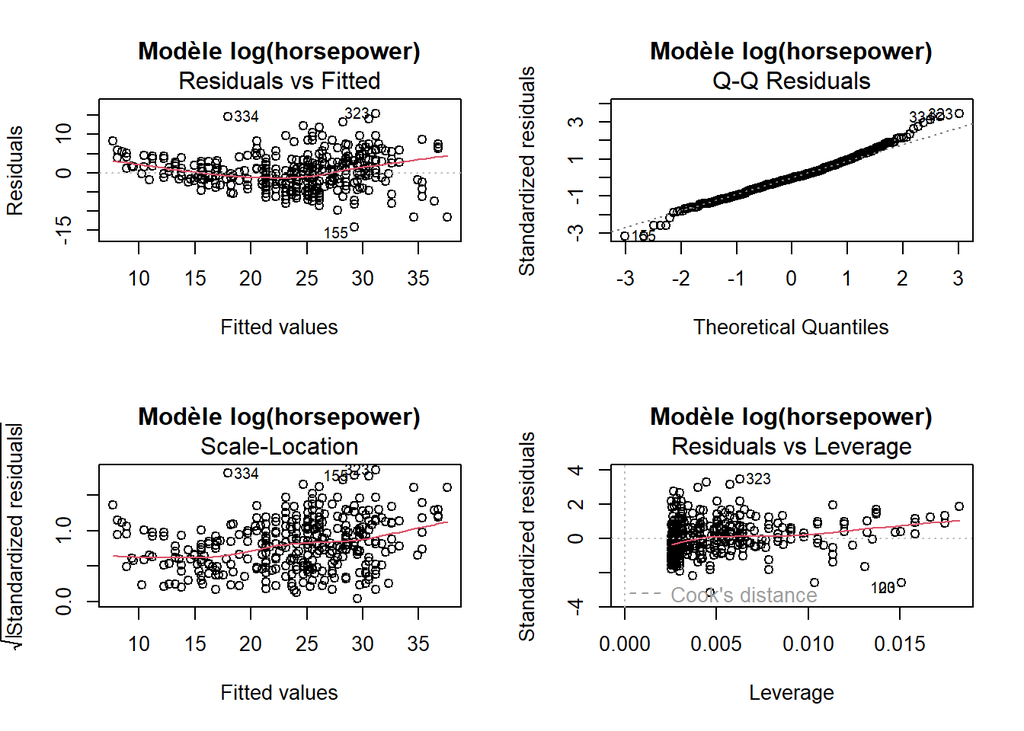

```r
par(mfrow = c(2, 2))
plot(model_log, main = "Modèle log(horsepower)")
```

Transformation racine carrée :Le modèle avec sqrt(horsepower) réduire l’impact des valeurs élevées, améliore la linéarité de la relation ce qui améliore la répartition des résidus.

```r
# Modèle avec racine carrée de horsepower
model_sqrt <- lm(mpg ~ sqrt(horsepower), data = Auto)
summary(model_sqrt)
```

```
##
## Call:
## lm(formula = mpg ~ sqrt(horsepower), data = Auto)
##
## Residuals:
##      Min       1Q   Median       3Q      Max
## -13.9768  -3.2239  -0.2252   2.6881  16.1411
##
## Coefficients:
##                  Estimate Std. Error t value Pr(>|t|)
## (Intercept)        58.705      1.349   43.52   <2e-16 ***
## sqrt(horsepower)   -3.503      0.132  -26.54   <2e-16 ***
## ---
## Signif. codes:  0 '***' 0.001 '**' 0.01 '*' 0.05 '.' 0.1 ' ' 1
##
## Residual standard error: 4.665 on 390 degrees of freedom
## Multiple R-squared:  0.6437, Adjusted R-squared:  0.6428
## F-statistic: 704.6 on 1 and 390 DF,  p-value: < 2.2e-16
```

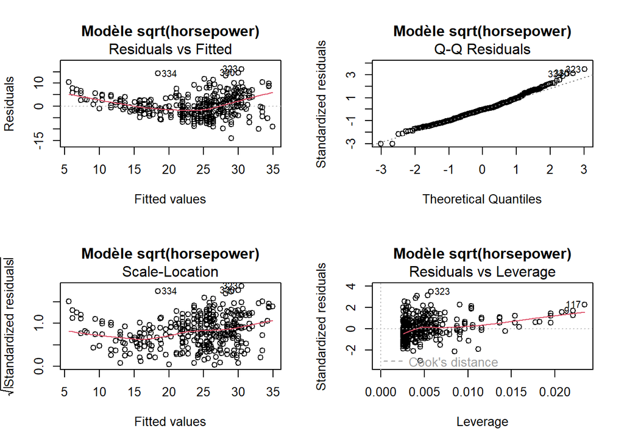

```r
par(mfrow = c(2, 2))
plot(model_sqrt, main = "Modèle sqrt(horsepower)")
```

Transformation au carré :cette transformation ne semble généralement pas apporter une signification, et le terme peut même rendre l’interprétation plus complexe.

```r
# Modèle avec horsepower au carré
model_sq <- lm(mpg ~ I(horsepower^2), data = Auto)
summary(model_sq)
```

```
##
## Call:
## lm(formula = mpg ~ I(horsepower^2), data = Auto)
##
## Residuals:
##     Min      1Q  Median      3Q     Max
## -12.529  -3.798  -1.049   3.240  18.528
##
## Coefficients:
##                   Estimate Std. Error t value Pr(>|t|)
## (Intercept)      3.047e+01  4.466e-01   68.22   <2e-16 ***
## I(horsepower^2) -5.665e-04  2.827e-05  -20.04   <2e-16 ***
## ---
## Signif. codes:  0 '***' 0.001 '**' 0.01 '*' 0.05 '.' 0.1 ' ' 1
##
## Residual standard error: 5.485 on 390 degrees of freedom
## Multiple R-squared:  0.5074, Adjusted R-squared:  0.5061
## F-statistic: 401.7 on 1 and 390 DF,  p-value: < 2.2e-16
```

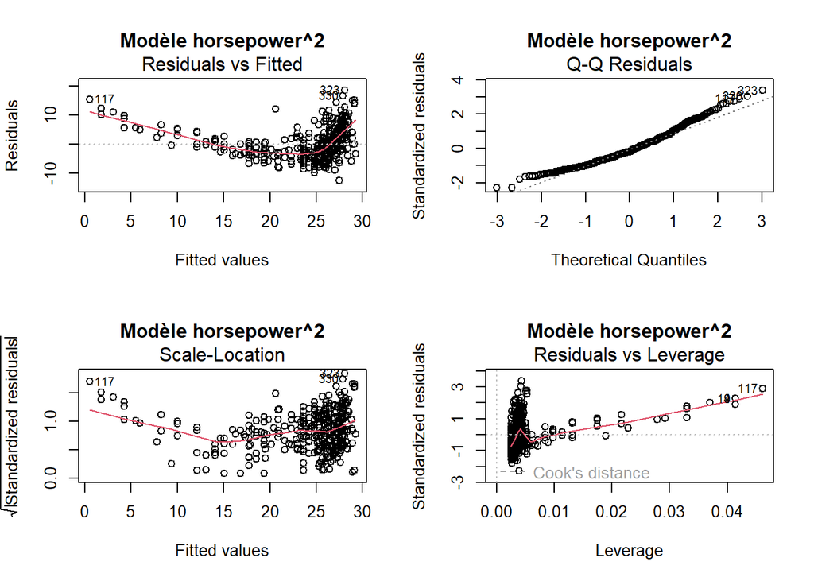

```r
par(mfrow = c(2, 2))
plot(model_sq, main = "Modèle horsepower^2")
```

### Question 3

#### a)

Ajustons un modèle de régression multiple pour prédire les « Ventes » en utilisant « Prix », « Urbain » et « États-Unis ».

Nous allons ajuster le modèle de regression multiple utiliser la haut

```r
data(Carseats)
#Ajustons le modele utiliser la haut
modele_carseats <- lm(Sales ~ Price + Urban + US, data = Carseats)
summary(modele_carseats)
```

```
##
## Call:
## lm(formula = Sales ~ Price + Urban + US, data = Carseats)
##
## Residuals:
##     Min      1Q  Median      3Q     Max
## -6.9206 -1.6220 -0.0564  1.5786  7.0581
##
## Coefficients:
##              Estimate Std. Error t value Pr(>|t|)
## (Intercept) 13.043469   0.651012  20.036  < 2e-16 ***
## Price       -0.054459   0.005242 -10.389  < 2e-16 ***
## UrbanYes    -0.021916   0.271650  -0.081    0.936
## USYes        1.200573   0.259042   4.635 4.86e-06 ***
## ---
## Signif. codes:  0 '***' 0.001 '**' 0.01 '*' 0.05 '.' 0.1 ' ' 1
##
## Residual standard error: 2.472 on 396 degrees of freedom
## Multiple R-squared:  0.2393, Adjusted R-squared:  0.2335
## F-statistic: 41.52 on 3 and 396 DF,  p-value: < 2.2e-16
```

#### b)

Fournissons une interprétation de chaque coefficient du modèle. Soyons prudent : certaines variables du modèle sont qualitatives !

Price: -0.054459 Pour chaque augmentation d’une unité du prix, en maintenant constantes toutes les autres variables, les ventes prédites diminuent en moyenne de 0.054459 unité. Cela indique que le prix a un effet négatif sur les ventes.

USYes : 1.200573 Cette variable indicatrice vaut 1 pour les magasins situés aux États‑Unis (US = Yes) et 0 pour ceux hors des États‑Unis (US = Ne). Le coefficient de 1.200573 indique qu’en moyenne, les magasins situés aux États-Unis affichent des ventes prédites supérieures de 1.200573 unité par rapport aux magasins non américains, toutes choses étant égales par ailleurs. Cet effet est très significatif car p-value < 2e‑1).

```r
modele_carseats <- lm(Sales ~ Price + Urban + US, data = Carseats)
summary(modele_carseats)
```

```
##
## Call:
## lm(formula = Sales ~ Price + Urban + US, data = Carseats)
##
## Residuals:
##     Min      1Q  Median      3Q     Max
## -6.9206 -1.6220 -0.0564  1.5786  7.0581
##
## Coefficients:
##              Estimate Std. Error t value Pr(>|t|)
## (Intercept) 13.043469   0.651012  20.036  < 2e-16 ***
## Price       -0.054459   0.005242 -10.389  < 2e-16 ***
## UrbanYes    -0.021916   0.271650  -0.081    0.936
## USYes        1.200573   0.259042   4.635 4.86e-06 ***
## ---
## Signif. codes:  0 '***' 0.001 '**' 0.01 '*' 0.05 '.' 0.1 ' ' 1
##
## Residual standard error: 2.472 on 396 degrees of freedom
## Multiple R-squared:  0.2393, Adjusted R-squared:  0.2335
## F-statistic: 41.52 on 3 and 396 DF,  p-value: < 2.2e-16
```

#### c)

Écrivons le modèle sous forme d’équation, en prenant soin de gérer correctement les variables qualitatives.

Sales= coef(Intercept) + coef(price)*price + coef(UrbanNo)*(Urban=no) + coef(USYes)*(US= yes).

En application:

NB:(Urban=No) vaut 1 si le magasin n’est pas en zone urbaine sinon elle vaut 0 si (Urban = Yes). -(US=YES) vaut 1 si le magasin est situé aux États-Unis sinon elle vaut 0 si (US = NO).

#### d)

Pour lequel des prédicteurs pouvez-vous rejeter l’hypothèse nulle H₀ : Bⱼ = 0 ?

D’après le résumé du modèle sur l’ensemble de données Carseats price et us ont les plus faibles p-value, donc nous pouvons rejeter l’hypothèse nulle H₀ : Bⱼ = 0 pour les variables Price et US.

#### e)

Sur la base de notre réponse à la question précédente, ajustons un modèle plus petit qui utilise uniquement les prédicteurs pour lesquels il existe des preuves d’association avec le résultat.

Ajustons le modèle réduit en ne retenant que les prédicteurs significatifs (Price et US) :

```r
data(Carseats)
modele_carseats_small <- lm(Sales ~ Price + US, data = Carseats)
summary(modele_carseats_small)
```

```
##
## Call:
## lm(formula = Sales ~ Price + US, data = Carseats)
##
## Residuals:
##     Min      1Q  Median      3Q     Max
## -6.9269 -1.6286 -0.0574  1.5766  7.0515
##
## Coefficients:
##             Estimate Std. Error t value Pr(>|t|)
## (Intercept) 13.03079    0.63098  20.652  < 2e-16 ***
## Price       -0.05448    0.00523 -10.416  < 2e-16 ***
## USYes        1.19964    0.25846   4.641 4.71e-06 ***
## ---
## Signif. codes:  0 '***' 0.001 '**' 0.01 '*' 0.05 '.' 0.1 ' ' 1
##
## Residual standard error: 2.469 on 397 degrees of freedom
## Multiple R-squared:  0.2393, Adjusted R-squared:  0.2354
## F-statistic: 62.43 on 2 and 397 DF,  p-value: < 2.2e-16
```

#### f)

Dans quelle mesure les modèles (a) et (e) s’ajustent-ils aux données ?

En gros la capacité prédictive du modèle est quasiment la même que l’on utilise ou non la variable Urban, ce qui confirme que seuls Price et US apportent une information significative pour expliquer Sales.

#### g)

À l’aide du modèle de (e), obtenons des intervalles de confiance de 95 % pour le(s) coefficient(s).

```r
data(Carseats)
modele_carseats_small <- lm(Sales ~ Price + US, data = Carseats)
confint(modele_carseats_small, level = 0.95)
```

```
##                   2.5 %      97.5 %
## (Intercept) 11.79032020 14.27126531
## Price       -0.06475984 -0.04419543
## USYes        0.69151957  1.70776632
```

#### h)

Existe-t-il des preuves de valeurs aberrantes ou d’observations à effet de levier élevé dans le modèle de (e) ?

Le graphique “Residuals vs Fitted” montre que les résidus sont bien répartis sans points extrêmes. Le “Normal QQ Plot” indique que les résidus suivent globalement une distribution normale.

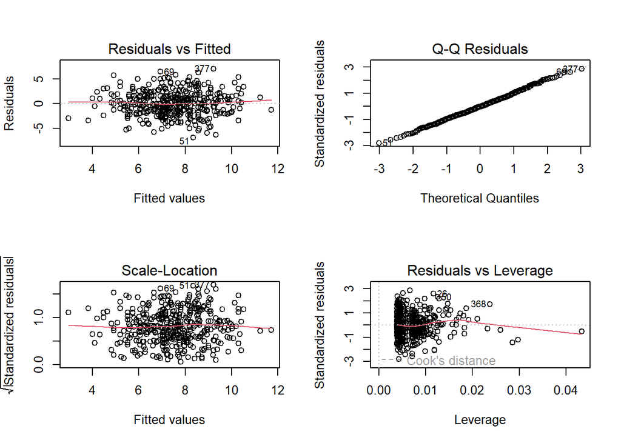

```r
data(Carseats)
modele_carseats_small <- lm(Sales ~ Price + US, data = Carseats)
par(mfrow = c(2, 2))
plot(modele_carseats_small)
```

### Question 4

```r
  set.seed(1)
  x <- rnorm(100)
  y <- 2 * x + rnorm(100)
```

#### a)

Regression lineaire sans intercept de y sur x

```r
modele_lin_yx <- lm(y~x+0)
summary(modele_lin_yx)
```

```
##
## Call:
## lm(formula = y ~ x + 0)
##
## Residuals:
##     Min      1Q  Median      3Q     Max
## -1.9154 -0.6472 -0.1771  0.5056  2.3109
##
## Coefficients:
##   Estimate Std. Error t value Pr(>|t|)
## x   1.9939     0.1065   18.73   <2e-16 ***
## ---
## Signif. codes:  0 '***' 0.001 '**' 0.01 '*' 0.05 '.' 0.1 ' ' 1
##
## Residual standard error: 0.9586 on 99 degrees of freedom
## Multiple R-squared:  0.7798, Adjusted R-squared:  0.7776
## F-statistic: 350.7 on 1 and 99 DF,  p-value: < 2.2e-16
```

- Estimation du coefficient : **beta1_hat = 1.9939**,

*erreur type : **std = 0.1065**,

- statistique t : **t = 18.73**,

*p-value : **p < 2e-16**

- Commentaire : Il existe une correlation positive entre x et y. La p-value est extremement faible, ce qui signifie que nous rejetons l’hypothese nulle (beta1 = 0) ==> il y a une forte correlation lineaire entre ces deux variables, et le coefficient estimé est significativement différent de 0.

#### b)

Regression lineaire sans intercept de x sur y

```r
modele_lin_xy <- lm(x~y+0)
summary(modele_lin_xy)
```

```
##
## Call:
## lm(formula = x ~ y + 0)
##
## Residuals:
##     Min      1Q  Median      3Q     Max
## -0.8699 -0.2368  0.1030  0.2858  0.8938
##
## Coefficients:
##   Estimate Std. Error t value Pr(>|t|)
## y  0.39111    0.02089   18.73   <2e-16 ***
## ---
## Signif. codes:  0 '***' 0.001 '**' 0.01 '*' 0.05 '.' 0.1 ' ' 1
##
## Residual standard error: 0.4246 on 99 degrees of freedom
## Multiple R-squared:  0.7798, Adjusted R-squared:  0.7776
## F-statistic: 350.7 on 1 and 99 DF,  p-value: < 2.2e-16
```

- Estimation du coefficient : **beta1_hat = 0.39111**
- erreur type : **std = 0.02089**
- statistique t : **t = 18.73**
- p-value : **p <2e-16**
- Commentaire : Il existe une correlation positive entre x et y. La p-value est extremement faible, ce qui signifie que nous rejetons l’hypothese nulle (beta_1 = 0) ==> il y a une forte correlation lineaire entre ces deux variables, et le coefficient estimé est significativement différent de 0.

#### c)

Les deux relations ont la même statistique t et la meme p-value. De plus, le produit des deux coefficient est égal à R^2

R^2= 0.7798 et beta1_xy * beta1-yx = 0.7798

#### d)

Question manquante

#### e)

Question manquante

#### f)

Dans R, montrez que lorsque la régression est effectuée avec un intercept la statistique t pour est la même pour la régression de y sur x que pour la régression de x sur y.

- Regression linéaire de y sur x avec intercept :

** Regression linéaire de x sur y avec intercept :

### Question 5

#### a)

Dans quelles circonstances l’estimation du coefficient pour la régression de y sur x est-elle la même que l’estimation du coefficient pour la régression de x sur y ?

- coefficient de correlation de y sur x :
  $$b_{yx}1 =
  \frac{cov(x,y)}{V(x)}$$
- coefficient de correlation de x sur y :
  $$b_{xy}1 =
  \frac{cov(x,y)}{V(y)}$$
- $$b_{yx}1 = b_{xy}1 \iff V(x) =
  V(y)$$

l’estimation du coefficient pour la régression de Y sur X est la même que celle de la régression de X sur Y lorsque les variances de x et y sont égales.

#### b)

Générons un exemple dans R avec des observations dans lequel l’estimation du coefficient pour la régression de y sur x est différente de l’estimation du coefficient pour la régression de x sur y .

```r
#Exemple : Y = 2 * X (donc c = 2)
set.seed(123)
x <- rnorm(100)
y <- 2 * x

#La régression sans intercept de Y sur X
model_y_on_x <- lm(y ~ 0 + x)
coef_y_on_x <- coef(model_y_on_x)

#La régression sans intercept de X sur Y
model_x_on_y <- lm(x ~ 0 + y)
coef_x_on_y <- coef(model_x_on_y)

cat("Coefficient pour la régression de Y sur X :", round(coef_y_on_x, 3), "\n")
```

```
## Coefficient pour la régression de Y sur X : 2
```

```r
cat("Coefficient pour la régression de X sur Y :", round(coef_x_on_y, 3), "\n")
```

```
## Coefficient pour la régression de X sur Y : 0.5
```

#### c)

Générons un exemple dans R avec des observations dans lequel l’estimation du coefficient pour la régression de y sur x est la même que l’estimation du coefficient pour la régression de x sur y.

```r
set.seed(123)
x <- rnorm(100)
y <- x  #Y est exactement égal à X

#La régression sans intercept de Y sur X
modele_Y_on_X <- lm(y ~ 0 + x)
coef_Y_on_X <- coef(modele_Y_on_X)

#La régression sans intercept de X sur Y
modele_X_on_Y <- lm(x ~ 0 + y)
coef_X_on_Y <- coef(modele_X_on_Y)

cat("Coefficient pour la régression de Y sur X :", round(coef_Y_on_X, 3), "\n")
```

```
## Coefficient pour la régression de Y sur X : 1
```

```r
cat("Coefficient pour la régression de X sur Y :", round(coef_X_on_Y, 3), "\n")
```

```
## Coefficient pour la régression de X sur Y : 1
```

### Question 6

#### a)

Pour créer un vecteur x de 100 observations tirées d’une distribution normale standard (N(0,1)) en assurant la reproductibilité, on vas utiliser :

```r
set.seed(1)
x <- rnorm(100)
```

#### b)

Pour créer un vecteur eps de 100 observations issues d’une distribution normale avec une moyenne nulle et une variance de 0,25 (donc un écart type de 0,5), ont vas utiliser :

```r
eps <- rnorm(100, mean = 0, sd = 0.5)
```

#### c)

En utilisant x et eps, générons un vecteur y selon le modèle Quelle est la longueur du vecteur y ? la longueur est 100

```r
y <- 2 + 2 * x + eps
length(y)
```

```
## [1] 100
```

#### d)

Le graphique montre une relation linéaire positive entre x et y, ce qui est conforme au modèle générateur x=2+2𝑥+𝜖de plus aucun comportement non linéaire ni valeurs aberrantes marquées ne semblent apparaître, ce qui confirme que la relation entre x et y est bien linéaire

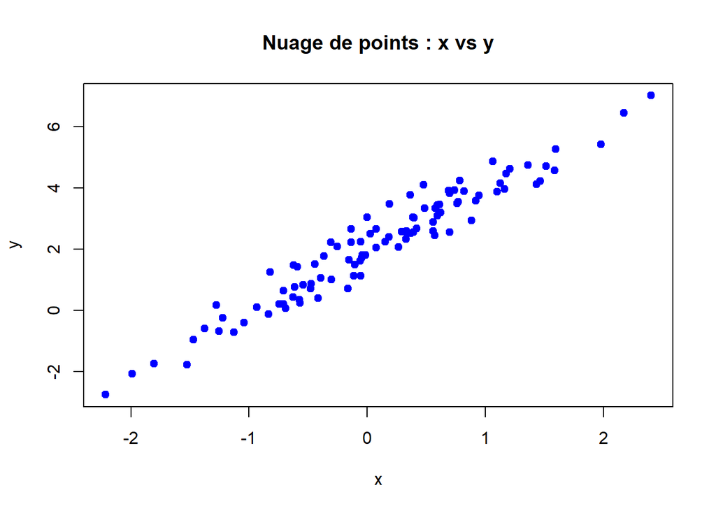

```r
plot(x, y, main = "Nuage de points : x vs y", xlab = "x", ylab = "y", pch = 19, col = "blue")
```

#### e)

```r
set.seed(1)
x <- rnorm(100)
eps <- rnorm(100, mean = 0, sd = 0.5)
y <- 2 + 2 * x + eps
modele <- lm(y ~ x)
summary(modele)
```

```
##
## Call:
## lm(formula = y ~ x)
##
## Residuals:
##      Min       1Q   Median       3Q      Max
## -0.93842 -0.30688 -0.06975  0.26970  1.17309
##
## Coefficients:
##             Estimate Std. Error t value Pr(>|t|)
## (Intercept)  1.98115    0.04849   40.85   <2e-16 ***
## x            1.99947    0.05386   37.12   <2e-16 ***
## ---
## Signif. codes:  0 '***' 0.001 '**' 0.01 '*' 0.05 '.' 0.1 ' ' 1
##
## Residual standard error: 0.4814 on 98 degrees of freedom
## Multiple R-squared:  0.9336, Adjusted R-squared:  0.9329
## F-statistic:  1378 on 1 and 98 DF,  p-value: < 2.2e-16
```

#### f)

le nuage de points, ajoute la ligne de régression obtenue par les moindres carrés (modèle ajusté) et la vraie ligne de régression

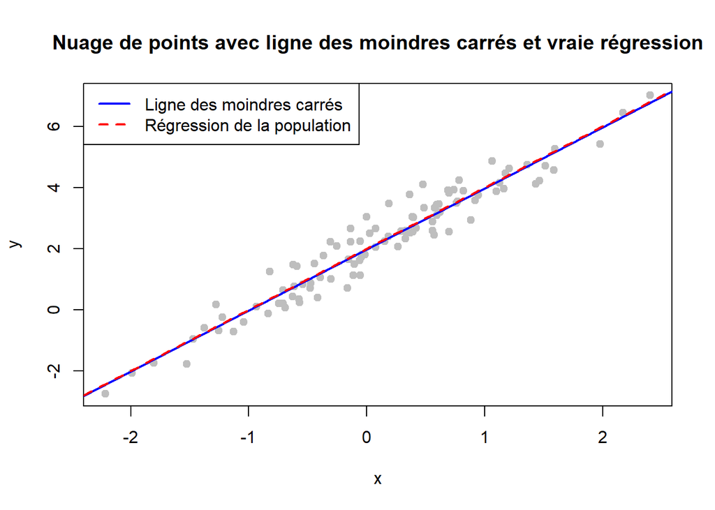

```r
set.seed(1)
x <- rnorm(100)
eps <- rnorm(100, mean = 0, sd = 0.5)
y <- 2 + 2 * x + eps
plot(x, y, main = "Nuage de points avec ligne des moindres carrés et vraie régression",
     xlab = "x", ylab = "y", pch = 19, col = "gray")
modele <- lm(y ~ x)
abline(modele, col = "blue", lwd = 2)
abline(a = 2, b = 2, col = "red", lwd = 2, lty = 2)

#on ajout d'une légende
legend("topleft", legend = c("Ligne des moindres carrés", "Régression de la population"),
       col = c("blue", "red"), lty = c(1, 2), lwd = 2)
```

#### g)

Explication: le modèle générateur est x=2+2 x+ϵ(donc linéaire) et l’ajout du terme x² n’a pas apporter d’amélioration significative. Or dans le modèle polynomial, le coefficient associé à I(x²) permet d’évaluer l’effet quadratique. Si ce coefficient n’est pas statistiquement significatif (p-value > 0.05) et si le test d’ANOVA (comparaison entre le modèle linéaire et le modèle polynomial) ne montre pas une significative (p-value > 0.05), cela indique qu’il n’existe pas de preuves que le terme quadratique améliore l’ajustement du modèle.

```r
set.seed(1)
x <- rnorm(100)
eps <- rnorm(100, mean = 0, sd = 0.5)
y <- 2 + 2 * x + eps
model_linear <- lm(y ~ x)
model_poly <- lm(y ~ x + I(x^2))

summary(model_linear)
```

```
##
## Call:
## lm(formula = y ~ x)
##
## Residuals:
##      Min       1Q   Median       3Q      Max
## -0.93842 -0.30688 -0.06975  0.26970  1.17309
##
## Coefficients:
##             Estimate Std. Error t value Pr(>|t|)
## (Intercept)  1.98115    0.04849   40.85   <2e-16 ***
## x            1.99947    0.05386   37.12   <2e-16 ***
## ---
## Signif. codes:  0 '***' 0.001 '**' 0.01 '*' 0.05 '.' 0.1 ' ' 1
##
## Residual standard error: 0.4814 on 98 degrees of freedom
## Multiple R-squared:  0.9336, Adjusted R-squared:  0.9329
## F-statistic:  1378 on 1 and 98 DF,  p-value: < 2.2e-16
```

```r
summary(model_poly)
```

```
##
## Call:
## lm(formula = y ~ x + I(x^2))
##
## Residuals:
##      Min       1Q   Median       3Q      Max
## -0.98252 -0.31270 -0.06441  0.29014  1.13500
##
## Coefficients:
##             Estimate Std. Error t value Pr(>|t|)
## (Intercept)  2.02836    0.05883  34.480   <2e-16 ***
## x            2.00858    0.05399  37.202   <2e-16 ***
## I(x^2)      -0.05946    0.04238  -1.403    0.164
## ---
## Signif. codes:  0 '***' 0.001 '**' 0.01 '*' 0.05 '.' 0.1 ' ' 1
##
## Residual standard error: 0.479 on 97 degrees of freedom
## Multiple R-squared:  0.9349, Adjusted R-squared:  0.9336
## F-statistic: 696.8 on 2 and 97 DF,  p-value: < 2.2e-16
```

```r
anova(model_linear, model_poly)
```

```
## Analysis of Variance Table
##
## Model 1: y ~ x
## Model 2: y ~ x + I(x^2)
##   Res.Df    RSS Df Sum of Sq      F Pr(>F)
## 1     98 22.709
## 2     97 22.257  1   0.45163 1.9682 0.1638
```

#### h)

En diminuant la variance du terme d’erreur, on obtient des estimations plus précises et un meilleur ajustement global du modèle aux données, tout en confirmant que le modèle linéaire simple est bien adapté à la structure de la relation simulée.

```r
#(a) Générons des données avec moins de bruit
set.seed(1)
x <- rnorm(100)
eps <- rnorm(100, mean = 0, sd = 0.25)
y <- 2 + 2 * x + eps

#(b) Vérification de la longueur y=100
length(y)
```

```
## [1] 100
```

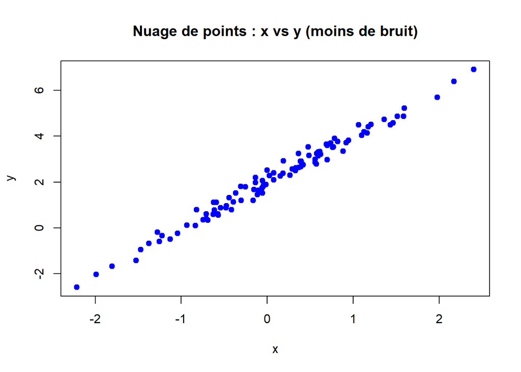

```r
#(c) Nuage de points
plot(x, y, main = "Nuage de points : x vs y (moins de bruit)",
     xlab = "x", ylab = "y", pch = 19, col = "blue")
```

```r
#(d) Ajustement d'un modèle linéaire simple
model_linear <- lm(y ~ x)
summary(model_linear)
```

```
##
## Call:
## lm(formula = y ~ x)
##
## Residuals:
##      Min       1Q   Median       3Q      Max
## -0.46921 -0.15344 -0.03487  0.13485  0.58654
##
## Coefficients:
##             Estimate Std. Error t value Pr(>|t|)
## (Intercept)  1.99058    0.02425   82.10   <2e-16 ***
## x            1.99973    0.02693   74.25   <2e-16 ***
## ---
## Signif. codes:  0 '***' 0.001 '**' 0.01 '*' 0.05 '.' 0.1 ' ' 1
##
## Residual standard error: 0.2407 on 98 degrees of freedom
## Multiple R-squared:  0.9825, Adjusted R-squared:  0.9824
## F-statistic:  5513 on 1 and 98 DF,  p-value: < 2.2e-16
```

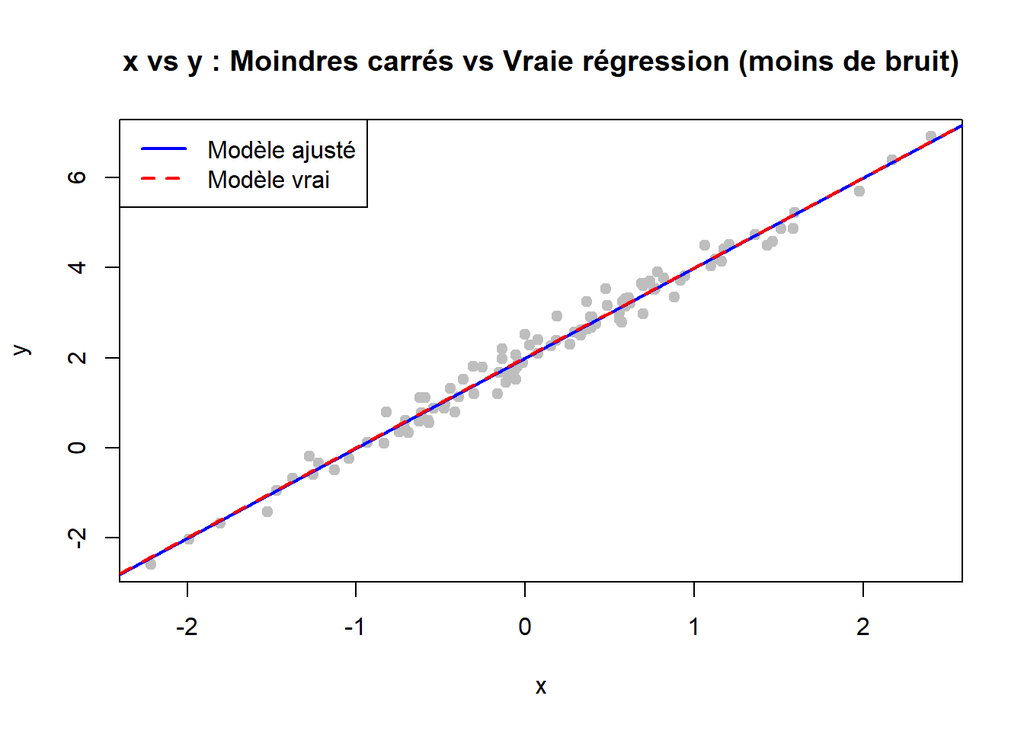

```r
#(e) Ajoutons de la droite des moindres carrés et de la vraie ligne de régression
plot(x, y, main = "x vs y : Moindres carrés vs Vraie régression (moins de bruit)",
     xlab = "x", ylab = "y", pch = 19, col = "gray")
abline(model_linear, col = "blue", lwd = 2)
abline(a = 2, b = 2, col = "red", lwd = 2, lty = 2)
legend("topleft", legend = c("Modèle ajusté", "Modèle vrai"),
       col = c("blue", "red"), lty = c(1, 2), lwd = 2)
```

```r
#(f) Ajustement d'un modèle de régression polynomiale (avec x et x^2) et comparaison
model_poly <- lm(y ~ x + I(x^2))
summary(model_poly)
```

```
##
## Call:
## lm(formula = y ~ x + I(x^2))
##
## Residuals:
##     Min      1Q  Median      3Q     Max
## -0.4913 -0.1563 -0.0322  0.1451  0.5675
##
## Coefficients:
##             Estimate Std. Error t value Pr(>|t|)
## (Intercept)  2.01418    0.02941  68.477   <2e-16 ***
## x            2.00429    0.02700  74.245   <2e-16 ***
## I(x^2)      -0.02973    0.02119  -1.403    0.164
## ---
## Signif. codes:  0 '***' 0.001 '**' 0.01 '*' 0.05 '.' 0.1 ' ' 1
##
## Residual standard error: 0.2395 on 97 degrees of freedom
## Multiple R-squared:  0.9829, Adjusted R-squared:  0.9825
## F-statistic:  2785 on 2 and 97 DF,  p-value: < 2.2e-16
```

```r
anova(model_linear, model_poly)
```

```
## Analysis of Variance Table
##
## Model 1: y ~ x
## Model 2: y ~ x + I(x^2)
##   Res.Df    RSS Df Sum of Sq      F Pr(>F)
## 1     98 5.6772
## 2     97 5.5643  1   0.11291 1.9682 0.1638
```

#### i)

Le fait d’augmenter la variance du terme d’erreur rend le modèle moins précis (erreurs standards plus élevées, R² plus faible), et le nuage de points montre une plus grande dispersion. Cependant, la relation linéaire reste clairement visible, et le modèle amélioré par moindres carrés reste cohérent avec le modèle théorique x=2+2 x+ϵ.

```r
#(a) Générons des données avec plus de bruit
set.seed(1)
x <- rnorm(100)
eps <- rnorm(100, mean = 0, sd = 1)
y <- 2 + 2 * x + eps

#(b) Vérification de la longueur du vecteur y=100
length(y)
```

```
## [1] 100
```

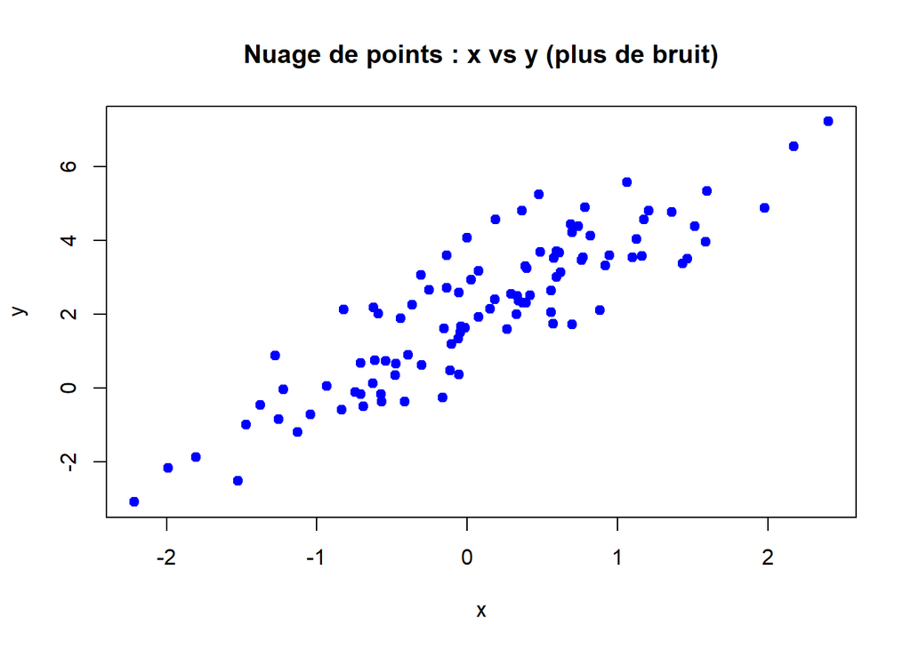

```r
#(c) Nuage de points entre x et y
plot(x, y, main = "Nuage de points : x vs y (plus de bruit)",
     xlab = "x", ylab = "y", pch = 19, col = "blue")
```

```r
#(d) Ajustement du modèle linéaire simple et résumé
model_linear <- lm(y ~ x)
summary(model_linear)
```

```
##
## Call:
## lm(formula = y ~ x)
##
## Residuals:
##     Min      1Q  Median      3Q     Max
## -1.8768 -0.6138 -0.1395  0.5394  2.3462
##
## Coefficients:
##             Estimate Std. Error t value Pr(>|t|)
## (Intercept)  1.96231    0.09699   20.23   <2e-16 ***
## x            1.99894    0.10773   18.56   <2e-16 ***
## ---
## Signif. codes:  0 '***' 0.001 '**' 0.01 '*' 0.05 '.' 0.1 ' ' 1
##
## Residual standard error: 0.9628 on 98 degrees of freedom
## Multiple R-squared:  0.7784, Adjusted R-squared:  0.7762
## F-statistic: 344.3 on 1 and 98 DF,  p-value: < 2.2e-16
```

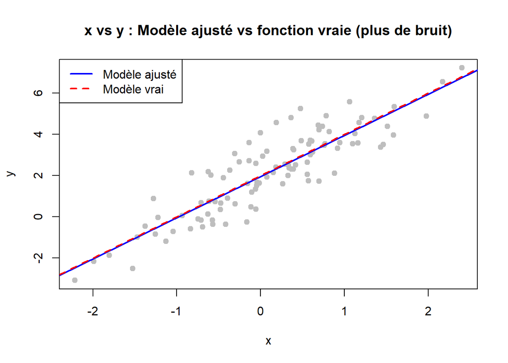

```r
#(e) Tracons les lignes :
plot(x, y, main = "x vs y : Modèle ajusté vs fonction vraie (plus de bruit)",
     xlab = "x", ylab = "y", pch = 19, col = "gray")
abline(model_linear, col = "blue", lwd = 2)
abline(a = 2, b = 2, col = "red", lwd = 2, lty = 2)
legend("topleft", legend = c("Modèle ajusté", "Modèle vrai"),
       col = c("blue", "red"), lty = c(1, 2), lwd = 2)
```

```r
#(f) Ajustement du modèle de régression polynomiale (incluant x et x^2)
model_poly <- lm(y ~ x + I(x^2))
summary(model_poly)
```

```
##
## Call:
## lm(formula = y ~ x + I(x^2))
##
## Residuals:
##     Min      1Q  Median      3Q     Max
## -1.9650 -0.6254 -0.1288  0.5803  2.2700
##
## Coefficients:
##             Estimate Std. Error t value Pr(>|t|)
## (Intercept)  2.05672    0.11766  17.481   <2e-16 ***
## x            2.01716    0.10798  18.680   <2e-16 ***
## I(x^2)      -0.11892    0.08477  -1.403    0.164
## ---
## Signif. codes:  0 '***' 0.001 '**' 0.01 '*' 0.05 '.' 0.1 ' ' 1
##
## Residual standard error: 0.958 on 97 degrees of freedom
## Multiple R-squared:  0.7828, Adjusted R-squared:  0.7784
## F-statistic: 174.8 on 2 and 97 DF,  p-value: < 2.2e-16
```

```r
#Comparaison entre le modèle linéaire simple et le modèle polynomial
anova(model_linear, model_poly)
```

```
## Analysis of Variance Table
##
## Model 1: y ~ x
## Model 2: y ~ x + I(x^2)
##   Res.Df    RSS Df Sum of Sq      F Pr(>F)
## 1     98 90.836
## 2     97 89.029  1    1.8065 1.9682 0.1638
```

#### j)

Explication: Dans le jeu de données avec moins de bruit , la dispersion autour de la droite de régression est plus faible. Par conséquent, les intervalles de confiance pour l’interception et le coefficient de x sont très étroits, reflétant une incertitude moindre dans les estimations.

Dans le jeu de données avec plus de bruit , la variabilité des observations autour de la droite est plus élevée, ce qui conduit à des erreurs standards plus grandes et à des intervalles de confiance plus larges. Les intervalles sont ainsi plus étendus, traduisant une incertitude accumulée dans l’estimation des coefficients.

Dans le jeu de données original , les intervalles se situent entre ceux obtenus avec moins de bruit et ceux obtenus avec plus de bruit, ce qui est cohérent avec le fait que la variance du terme d’erreur influe directement sur la précision des estimations.

Ces observations montrent clairement comment la quantité de bruit (variance de l’erreur) affecte la précision (et donc la largeur des intervalles de confiance) des coefficients estimés dans un modèle de régression linéaire.

```r
set.seed(1)
#Le Jeu de données original
x <- rnorm(100)
eps_original <- rnorm(100, mean = 0, sd = 0.5)
y_original <- 2 + 2 * x + eps_original
model_original <- lm(y_original ~ x)
ci_original <- confint(model_original, level = 0.95)
print("Intervalle de confiance (jeu de données original) :")
```

```
## [1] "Intervalle de confiance (jeu de données original) :"
```

```r
print(round(ci_original, 3))
```

```
##             2.5 % 97.5 %
## (Intercept) 1.885  2.077
## x           1.893  2.106
```

```r
#Le Jeu de données avec plus de bruit
eps_bruit <- rnorm(100, mean = 0, sd = 1)
y_bruit <- 2 + 2 * x + eps_bruit
model_bruit <- lm(y_bruit ~ x)
ci_bruit <- confint(model_bruit, level = 0.95)
print("Intervalle de confiance (jeu de données avec plus de bruit) :")
```

```
## [1] "Intervalle de confiance (jeu de données avec plus de bruit) :"
```

```r
print(round(ci_bruit, 3))
```

```
##             2.5 % 97.5 %
## (Intercept)  1.82  2.235
## x            1.79  2.252
```

```r
# Jeu de données avec moins de bruit (ε ~ N(0, 0.25²))
eps_mbruit <- rnorm(100, mean = 0, sd = 0.25)
y_mbruit <- 2 + 2 * x + eps_mbruit
model_mbruit <- lm(y_mbruit ~ x)
ci_mbruit <- confint(model_mbruit, level = 0.95)
print("Intervalle de confiance (jeu de données avec moins de bruit) :")
```

```
## [1] "Intervalle de confiance (jeu de données avec moins de bruit) :"
```

```r
print(round(ci_mbruit, 3))
```

```
##             2.5 % 97.5 %
## (Intercept) 1.965  2.064
## x           1.931  2.041
```

### Question 7

```r
set.seed(1)
x1 <-runif(100)
x2 <- 0.5 * x1 + rnorm(100) / 10
y <- 2 + 2 * x1 + 0.3 * x2 + rnorm(100)
```

#### a)

- forme du modele linéaire : y = 2 + 2x1 + 0.3 x2
- coefficients : intercept = 2, coeff de x1 = 2, coeff de x2 = 0.3

#### b)

correlation entre x1 et x2

- La correlation entre x1 et x2 est **corr(x,y) = 0.84**

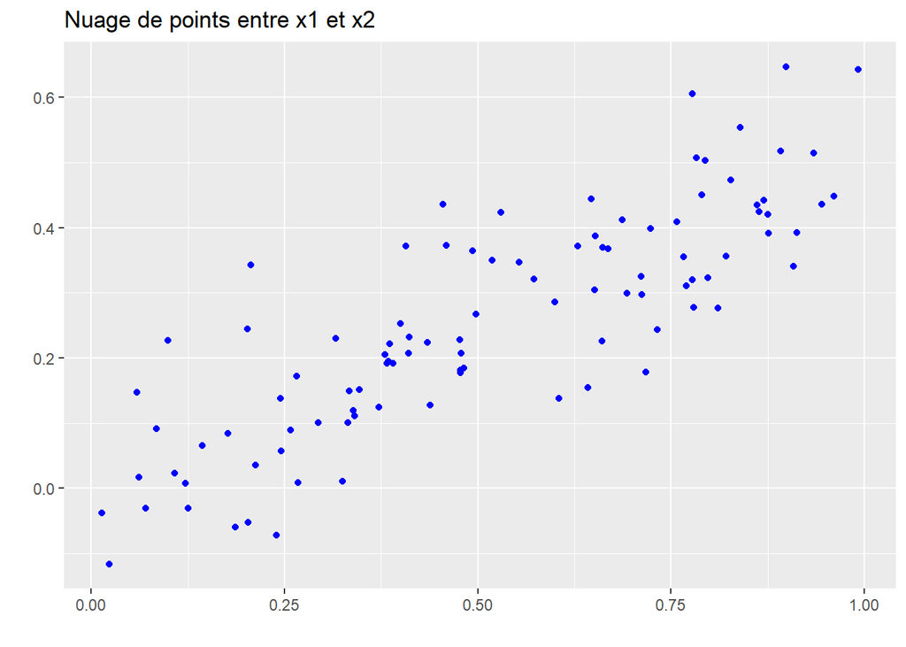

```r
data <- data.frame(x1, x2)
ggplot(data, aes(x=x1, y=x2)) +
  geom_point(color="blue") +
  labs(title = "Nuage de points entre x1 et x2",
       x = " ",
       y = " ")
```

#### d)

```r
modele_lmx1_x2 <- lm(y ~ x1 + x2)
summary(modele_lmx1_x2)
```

```
##
## Call:
## lm(formula = y ~ x1 + x2)
##
## Residuals:
##     Min      1Q  Median      3Q     Max
## -2.8311 -0.7273 -0.0537  0.6338  2.3359
##
## Coefficients:
##             Estimate Std. Error t value Pr(>|t|)
## (Intercept)   2.1305     0.2319   9.188 7.61e-15 ***
## x1            1.4396     0.7212   1.996   0.0487 *
## x2            1.0097     1.1337   0.891   0.3754
## ---
## Signif. codes:  0 '***' 0.001 '**' 0.01 '*' 0.05 '.' 0.1 ' ' 1
##
## Residual standard error: 1.056 on 97 degrees of freedom
## Multiple R-squared:  0.2088, Adjusted R-squared:  0.1925
## F-statistic:  12.8 on 2 and 97 DF,  p-value: 1.164e-05
```

#### d)

```r
modele_lm_x1 <- lm(y ~ x1)
summary(modele_lm_x1)
```

```
##
## Call:
## lm(formula = y ~ x1)
##
## Residuals:
##      Min       1Q   Median       3Q      Max
## -2.89495 -0.66874 -0.07785  0.59221  2.45560
##
## Coefficients:
##             Estimate Std. Error t value Pr(>|t|)
## (Intercept)   2.1124     0.2307   9.155 8.27e-15 ***
## x1            1.9759     0.3963   4.986 2.66e-06 ***
## ---
## Signif. codes:  0 '***' 0.001 '**' 0.01 '*' 0.05 '.' 0.1 ' ' 1
##
## Residual standard error: 1.055 on 98 degrees of freedom
## Multiple R-squared:  0.2024, Adjusted R-squared:  0.1942
## F-statistic: 24.86 on 1 and 98 DF,  p-value: 2.661e-06
```

Puisque la p-value associée à x1 est extrêmement faible, nous rejetons l’hypothèse nulle et concluons que x1 a un effet statistiquement significatif sur y

#### e)

```r
modele_lm_x2 <- lm(y ~ x2)
summary(modele_lm_x2)
```

```
##
## Call:
## lm(formula = y ~ x2)
##
## Residuals:
##      Min       1Q   Median       3Q      Max
## -2.62687 -0.75156 -0.03598  0.72383  2.44890
##
## Coefficients:
##             Estimate Std. Error t value Pr(>|t|)
## (Intercept)   2.3899     0.1949   12.26  < 2e-16 ***
## x2            2.8996     0.6330    4.58 1.37e-05 ***
## ---
## Signif. codes:  0 '***' 0.001 '**' 0.01 '*' 0.05 '.' 0.1 ' ' 1
##
## Residual standard error: 1.072 on 98 degrees of freedom
## Multiple R-squared:  0.1763, Adjusted R-squared:  0.1679
## F-statistic: 20.98 on 1 and 98 DF,  p-value: 1.366e-05
```

Puisque la p-value associée à x1 est extrêmement faible, nous rejetons l’hypothèse nulle et concluons que x2 a un effet statistiquement significatif sur y.

#### f)

Cette contradiction est du au fait de la multicolinéarité entre x1 et x2.

Seul, x2 a un effet significatif, mais combiné avec x2, son effet est négligeable par ce qu’il lui même expliqué par x1 via l’expression **x2 <- 0.5 * x1 + rnorm(100) / 10**

#### g)

code fourni non fonctionnel

### Question 8

#### a)

Trop long

#### b)

```r
head(Boston)
```

```
##      crim zn indus chas   nox    rm  age    dis rad tax ptratio lstat medv
## 1 0.00632 18  2.31    0 0.538 6.575 65.2 4.0900   1 296    15.3  4.98 24.0
## 2 0.02731  0  7.07    0 0.469 6.421 78.9 4.9671   2 242    17.8  9.14 21.6
## 3 0.02729  0  7.07    0 0.469 7.185 61.1 4.9671   2 242    17.8  4.03 34.7
## 4 0.03237  0  2.18    0 0.458 6.998 45.8 6.0622   3 222    18.7  2.94 33.4
## 5 0.06905  0  2.18    0 0.458 7.147 54.2 6.0622   3 222    18.7  5.33 36.2
## 6 0.02985  0  2.18    0 0.458 6.430 58.7 6.0622   3 222    18.7  5.21 28.7
```

```r
modele_lin <- lm(crim ~., data = Boston)
summary(modele_lin)
```

```
##
## Call:
## lm(formula = crim ~ ., data = Boston)
##
## Residuals:
##    Min     1Q Median     3Q    Max
## -8.534 -2.248 -0.348  1.087 73.923
##
## Coefficients:
##               Estimate Std. Error t value Pr(>|t|)
## (Intercept) 13.7783938  7.0818258   1.946 0.052271 .
## zn           0.0457100  0.0187903   2.433 0.015344 *
## indus       -0.0583501  0.0836351  -0.698 0.485709
## chas        -0.8253776  1.1833963  -0.697 0.485841
## nox         -9.9575865  5.2898242  -1.882 0.060370 .
## rm           0.6289107  0.6070924   1.036 0.300738
## age         -0.0008483  0.0179482  -0.047 0.962323
## dis         -1.0122467  0.2824676  -3.584 0.000373 ***
## rad          0.6124653  0.0875358   6.997 8.59e-12 ***
## tax         -0.0037756  0.0051723  -0.730 0.465757
## ptratio     -0.3040728  0.1863598  -1.632 0.103393
## lstat        0.1388006  0.0757213   1.833 0.067398 .
## medv        -0.2200564  0.0598240  -3.678 0.000261 ***
## ---
## Signif. codes:  0 '***' 0.001 '**' 0.01 '*' 0.05 '.' 0.1 ' ' 1
##
## Residual standard error: 6.46 on 493 degrees of freedom
## Multiple R-squared:  0.4493, Adjusted R-squared:  0.4359
## F-statistic: 33.52 on 12 and 493 DF,  p-value: < 2.2e-16
```